# Porównanie modeli uczenia maszynowego

Aleksandra Węgrzyn

2025-12-12

## 1. Wprowadzenie

W ramach niniejszego projektu dokonano budowy czterech modeli klasyfikacyjnych, obejmujących model k-najbliższych sąsiadów (KNN), regresję logistyczną, model maszyn wektorów nośnych (SVM) oraz drzewa decyzyjne. Celem badania była ocena oraz porównanie skuteczności wspomnianych modeli uczenia maszynowego w kontekście przewidywania prawdopodobieństwa odejścia klientów z banku.

W pracy postawiono następujące pytania badawcze:

- Jakie czynniki mają największy wpływ na decyzję klientów o odejściu z banku?
- Czy bardziej złożone modele m.in. drzewa decyzyjne umożliwiają uzyskanie lepszych wyników jakości klasyfikacji?
- Który z badanych modeli pozwala uzyskać najlepsze wyniki?
- Czy modele dostarczają podobnych rezultatów, a jeśli nie, to w jakich aspektach się różnią?
- Jakie wartości hiperparametrów dla wybranych modeli umożliwiają uzyskanie optymalnych wyników?

### 1.1. Opis zestawu danych

W analizie wykorzystano zestaw danych zawierający 10000 obserwacji opisanych za pomocą 13 zmiennych. Dwie z tych zmiennych, identyfikator oraz nazwisko, są unikalne i w związku z tym nie będą brane pod uwagę w badaniu. Ponadto, zbiór danych zawiera 6 zmiennych numerycznych, 2 zmienne kategoryczne oraz 3 zmienne binarne, z czego jedna będzie stanowić zmienną objaśnianą.

Charakterystyka zmiennych:

- **`CustomerId`**: unikalny identyfikator klienta
- **`Surname`**: nazwisko klienta
- **`CreditScore`**: ocena zdolności kredytowej klienta
- **`Country`**: kraj zamieszkania klienta; zmienna kategoryczna przyjmująca wartości: `Spain`, `Germany`, `France`
- **`Gender`**: płeć klienta
- **`Age`**: wiek klienta
- **`Tenure`**: liczba lat jako klient banku
- **`Balance`**: stan konta
- **`NumOfProducts`**: liczba produktów bankowych, z których korzysta klient
- **`HasCrCard`**: posiadanie karty kredytowej przez klienta; zmienna binarna przyjmująca wartość `1`, jeśli klient posiada kartę kredytową lub `0` w przeciwnym wypadku
- **`IsActiveMember`**: status aktywności klienta; zmienna binarna przyjmująca wartość `1`, jeśli klient jest aktywnym użytkownikiem lub `0` w przeciwnym wypadku
- **`EstimatedSalary`**: szacowane roczne wynagrodzenie klienta
- **`Exited`**: odejście klienta z banku; zmienna binarna przyjmująca wartość `1`, gdy klient decyduje się na odejście z banku lub `0` w przypadku pozostania

| CustomerId | Surname | CreditScore | Country | Gender | Age | Tenure | Balance | NumOfProducts | HasCrCard | IsActiveMember | EstimatedSalary | Exited |
| --- | --- | --- | --- | --- | --- | --- | --- | --- | --- | --- | --- | --- |
| 15634602 | Hargrave | 619 | France | Female | 42 | 2 | 0.00 | 1 | 1 | 1 | 101348.88 | 1 |
| 15647311 | Hill | 608 | Spain | Female | 41 | 1 | 83807.86 | 1 | 0 | 1 | 112542.58 | 0 |
| 15619304 | Onio | 502 | France | Female | 42 | 8 | 159660.80 | 3 | 1 | 0 | 113931.57 | 1 |
| 15701354 | Boni | 699 | France | Female | 39 | 1 | 0.00 | 2 | 0 | 0 | 93826.63 | 0 |
| 15737888 | Mitchell | 850 | Spain | Female | 43 | 2 | 125510.82 | 1 | 1 | 1 | 79084.10 | 0 |
| 15574012 | Chu | 645 | Spain | Male | 44 | 8 | 113755.78 | 2 | 1 | 0 | 149756.71 | 1 |
| 15592531 | Bartlett | 822 | France | Male | 50 | 7 | 0.00 | 2 | 1 | 1 | 10062.80 | 0 |
| 15656148 | Obinna | 376 | Germany | Female | 29 | 4 | 115046.74 | 4 | 1 | 0 | 119346.88 | 1 |
| 15792365 | He | 501 | France | Male | 44 | 4 | 142051.07 | 2 | 0 | 1 | 74940.50 | 0 |
| 15592389 | H? | 684 | France | Male | 27 | 2 | 134603.88 | 1 | 1 | 1 | 71725.73 | 0 |
| 15767821 | Bearce | 528 | France | Male | 31 | 6 | 102016.72 | 2 | 0 | 0 | 80181.12 | 0 |
| 15737173 | Andrews | 497 | Spain | Male | 24 | 3 | 0.00 | 2 | 1 | 0 | 76390.01 | 0 |
| 15632264 | Kay | 476 | France | Female | 34 | 10 | 0.00 | 2 | 1 | 0 | 26260.98 | 0 |
| 15691483 | Chin | 549 | France | Female | 25 | 5 | 0.00 | 2 | 0 | 0 | 190857.79 | 0 |
| 15600882 | Scott | 635 | Spain | Female | 35 | 7 | 0.00 | 2 | 1 | 1 | 65951.65 | 0 |
| 15643966 | Goforth | 616 | Germany | Male | 45 | 3 | 143129.41 | 2 | 0 | 1 | 64327.26 | 0 |
| 15737452 | Romeo | 653 | Germany | Male | 58 | 1 | 132602.88 | 1 | 1 | 0 | 5097.67 | 1 |
| 15788218 | Henderson | 549 | Spain | Female | 24 | 9 | 0.00 | 2 | 1 | 1 | 14406.41 | 0 |
| 15661507 | Muldrow | 587 | Spain | Male | 45 | 6 | 0.00 | 1 | 0 | 0 | 158684.81 | 0 |
| 15568982 | Hao | 726 | France | Female | 24 | 6 | 0.00 | 2 | 1 | 1 | 54724.03 | 0 |
| 15577657 | McDonald | 732 | France | Male | 41 | 8 | 0.00 | 2 | 1 | 1 | 170886.17 | 0 |
| 15597945 | Dellucci | 636 | Spain | Female | 32 | 8 | 0.00 | 2 | 1 | 0 | 138555.46 | 0 |
| 15699309 | Gerasimov | 510 | Spain | Female | 38 | 4 | 0.00 | 1 | 1 | 0 | 118913.53 | 1 |
| 15725737 | Mosman | 669 | France | Male | 46 | 3 | 0.00 | 2 | 0 | 1 | 8487.75 | 0 |
| 15625047 | Yen | 846 | France | Female | 38 | 5 | 0.00 | 1 | 1 | 1 | 187616.16 | 0 |
| 15738191 | Maclean | 577 | France | Male | 25 | 3 | 0.00 | 2 | 0 | 1 | 124508.29 | 0 |
| 15736816 | Young | 756 | Germany | Male | 36 | 2 | 136815.64 | 1 | 1 | 1 | 170041.95 | 0 |
| 15700772 | Nebechi | 571 | France | Male | 44 | 9 | 0.00 | 2 | 0 | 0 | 38433.35 | 0 |
| 15728693 | McWilliams | 574 | Germany | Female | 43 | 3 | 141349.43 | 1 | 1 | 1 | 100187.43 | 0 |
| 15656300 | Lucciano | 411 | France | Male | 29 | 0 | 59697.17 | 2 | 1 | 1 | 53483.21 | 0 |

[output cut: 70 more lines]

### 1.2. Wstępna analiza danych

Przygotowanie danych rozpoczęto od przeglądu struktury danych oraz występowania wartości brakujących. Przeprowadzona analiza nie ujawniła obecności braków danych w analizowanym zbiorze. Następnie, na potrzeby dalszej analizy, dokonano konwersji zmiennych kategorycznych na typ czynnikowy.

```
## 'data.frame':    10000 obs. of  11 variables:
##  $ CreditScore    : int  619 608 502 699 850 645 822 376 501 684 ...
##  $ Country        : chr  "France" "Spain" "France" "France" ...
##  $ Gender         : chr  "Female" "Female" "Female" "Female" ...
##  $ Age            : int  42 41 42 39 43 44 50 29 44 27 ...
##  $ Tenure         : int  2 1 8 1 2 8 7 4 4 2 ...
##  $ Balance        : num  0 83808 159661 0 125511 ...
##  $ NumOfProducts  : int  1 1 3 2 1 2 2 4 2 1 ...
##  $ HasCrCard      : int  1 0 1 0 1 1 1 1 0 1 ...
##  $ IsActiveMember : int  1 1 0 0 1 0 1 0 1 1 ...
##  $ EstimatedSalary: num  101349 112543 113932 93827 79084 ...
##  $ Exited         : int  1 0 1 0 0 1 0 1 0 0 ...
```

```
##     CreditScore         Country          Gender             Age          Tenure
##               0               0               0               0               0
##         Balance   NumOfProducts       HasCrCard  IsActiveMember EstimatedSalary
##               0               0               0               0               0
##          Exited
##               0
```

Następnie dokonano identyfikacji potencjalnych obserwacji odstających, tworząc w tym celu wykresy pudełkowe dla każdej zmiennej numerycznej oraz obliczono podstawowe statystyki opisowe dla analizowanych zmiennych. Uzyskane wyniki przedstawiono poniżej.

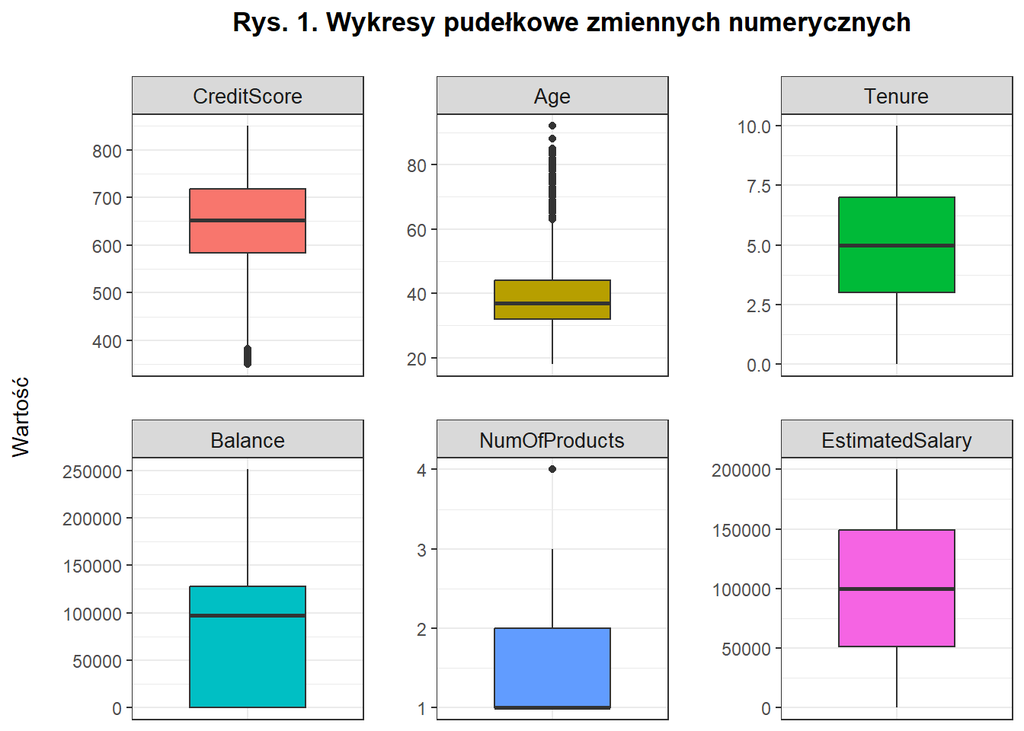

Na podstawie przedstawionych wykresów pudełkowych można zauważyć występowanie wartości odstających dla zmiennych **`Age`**, **`CreditScore`** oraz **`NumOfProducts.`** W każdym z tych przypadków wartości te wydają się być wiarygodne. W związku z tym nie zaleca się ich usuwania, gdyż mogą dostarczyć cennych informacji w kontekście klasyfikacji. Pozostałe zmienne nie posiadają obserwacji, które odbiegają od normy.

Tabela 1. Statystyki opisowe zmiennych numerycznych

|  | Średnia | Mediana | Min | Max | Odchylenie standardowe | Współczynnik zmienności | Skośność | Kurtoza |
| --- | --- | --- | --- | --- | --- | --- | --- | --- |
| CreditScore | 650.529 | 652.00 | 350.00 | 850.0 | 96.653 | 0.149 | -0.072 | -0.427 |
| Age | 38.922 | 37.00 | 18.00 | 92.0 | 10.488 | 0.269 | 1.011 | 1.393 |
| Tenure | 5.013 | 5.00 | 0.00 | 10.0 | 2.892 | 0.577 | 0.011 | -1.166 |
| Balance | 76485.889 | 97198.54 | 0.00 | 250898.1 | 62397.405 | 0.816 | -0.141 | -1.490 |
| NumOfProducts | 1.530 | 1.00 | 1.00 | 4.0 | 0.582 | 0.380 | 0.745 | 0.581 |
| EstimatedSalary | 100090.240 | 100193.91 | 11.58 | 199992.5 | 57510.493 | 0.575 | 0.002 | -1.182 |

W dalszej kolejności przeanalizowano rozkłady zmiennych kategorycznych przy zastosowaniu wykresów słupkowych przedstawiających liczności ich poszczególnych poziomów.

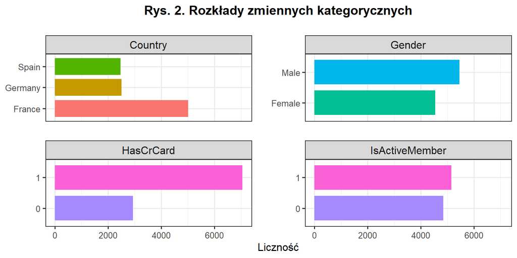

Analiza powyższych wizualizacji wskazuje, iż największa część klientów banku pochodzi z Francji, natomiast klienci z Hiszpanii oraz Niemiec stanowią grupy o podobnej liczności. W przypadku zmiennej **`HasCrCard`** obserwuje się znaczne różnice w poziomach, gdzie liczba klientów posiadających kartę kredytową jest ponad dwukrotnie wyższa od liczby klientów, którzy jej nie posiadają. Zmienne **`Gender`** i **`IsActiveMember`** wykazują stosunkowo zrównoważony rozkład, z podobnymi licznościami w poszczególnych kategoriach.

### 1.2. Analiza wpływu zmiennych objaśniających na zmienną objaśnianą

W celu zbadania wpływu poszczególnych zmiennych na zmienną wynikową przeprowadzono analizę ich rozkładów, w podziale na grupy wyodrębnione na podstawie przyjmowanych przez nią wartości. Dla każdej zmiennej przygotowano zestawienie obejmujące ujęcie ogólne dla wszystkich obserwacji, a także oddzielne analizy dla klientów, którzy pozostali w banku (`Exited` = 0) oraz tych, którzy zdecydowali się na odejście (`Exited` = 1).

#### 1.2.1. Analiza wpływu zmiennych numerycznych

Badanie rozpoczęto od analizy zmiennych numerycznych, w ramach której dla każdej zmiennej sporządzono wykresy pudełkowe oraz tabelę zawierającą statystyki opisowe. W celu ułatwienia interpretacji oraz porównania wyników, dane te zostały umieszczone w oddzielnych zakładkach.

##### CreditScore

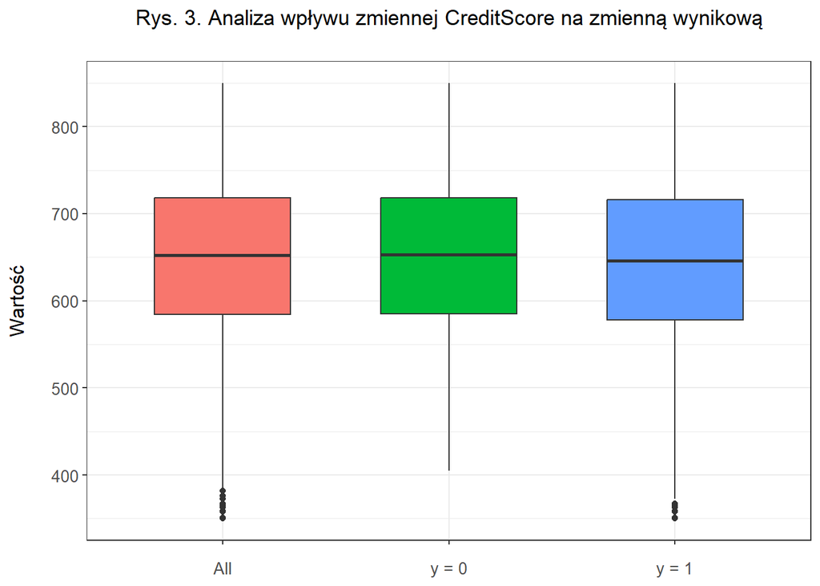

Tabela 2. Statystyki opisowe zmiennej CreditScore według wartości zmiennej wynikowej

|  | Średnia | Mediana | Min | Max | Odchylenie standardowe | Współczynnik zmienności | Skośność | Kurtoza |
| --- | --- | --- | --- | --- | --- | --- | --- | --- |
| All | 650.529 | 652 | 350 | 850 | 96.653 | 0.149 | -0.072 | -0.427 |
| y = 0 | 651.853 | 653 | 405 | 850 | 95.654 | 0.147 | -0.047 | -0.486 |
| y = 1 | 645.351 | 646 | 350 | 850 | 100.322 | 0.155 | -0.141 | -0.279 |

Dla zmiennej **`CreditScore`** wszystkie trzy wykresy pudełkowe wyglądają podobnie, jednak dostrzegalne są różnice na poziomie dolnego wąsa. W przypadku klientów, którzy pozostali w banku, zauważa się krótszą długość wąsa oraz brak wartości odstających, co znajduje potwierdzenie w statystykach opisowych zamieszczonych w tabeli, gdzie minimalna wartość zmiennej jest wyższa niż w pozostałych grupach. Może to sugerować, iż klienci o niższej zdolności kredytowej częściej odchodzą z banku.

##### Age

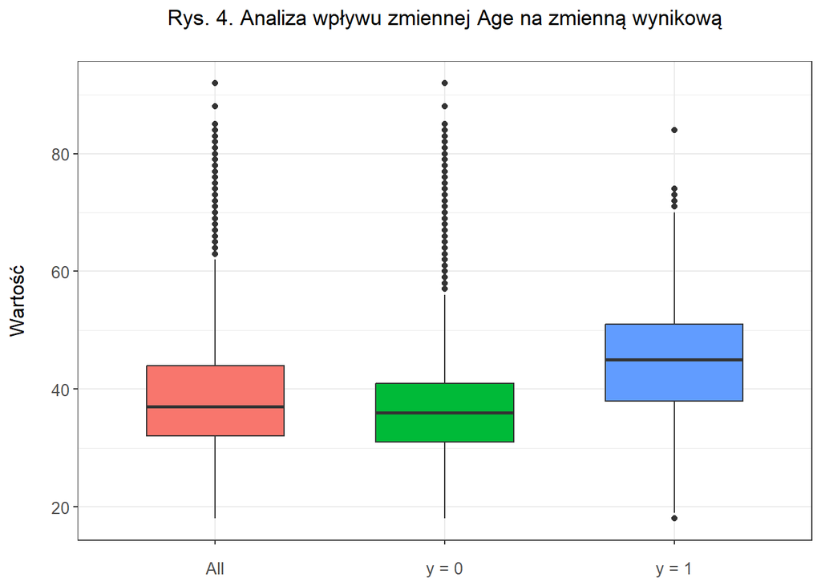

Tabela 3. Statystyki opisowe zmiennej Age według wartości zmiennej wynikowej

|  | Średnia | Mediana | Min | Max | Odchylenie standardowe | Współczynnik zmienności | Skośność | Kurtoza |
| --- | --- | --- | --- | --- | --- | --- | --- | --- |
| All | 38.922 | 37 | 18 | 92 | 10.488 | 0.269 | 1.011 | 1.393 |
| y = 0 | 37.408 | 36 | 18 | 92 | 10.125 | 0.271 | 1.377 | 2.846 |
| y = 1 | 44.838 | 45 | 18 | 84 | 9.762 | 0.218 | 0.078 | -0.128 |

Dla zmiennej **`Age`** wykresy pudełkowe wskazują na wyraźnie różnice w rozkładzie wieku pomiędzy klientami, którzy podjęli decyzję o odejściu z banku, a tymi, którzy pozostali. Grupa klientów, którzy zdecydowali się odejść, charakteryzuje się wyższymi wartościami wieku w porównaniu do grupy klientów, którzy zdecydowali się pozostać, co znajduje potwierdzenie w wartościach mediany i średniej arytmetycznej przedstawionych w tabeli. Sugeruje to, że osoby starsze mogą wykazywać większą skłonność do odejścia z banku. Niemniej jednak, wśród klientów, którzy postanowili pozostać w banku, znajduje się również wiele osób starszych, które w tym przypadku stanowią obserwacje odstające.

##### Tenure

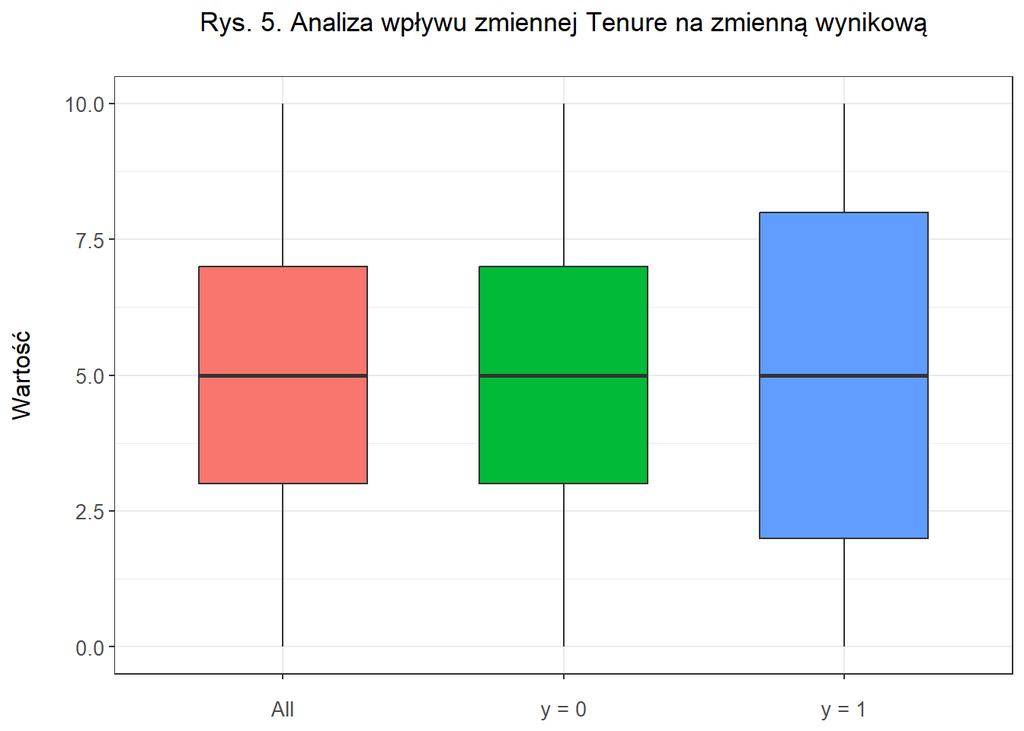

Tabela 4. Statystyki opisowe zmiennej Tenure według wartości zmiennej wynikowej

|  | Średnia | Mediana | Min | Max | Odchylenie standardowe | Współczynnik zmienności | Skośność | Kurtoza |
| --- | --- | --- | --- | --- | --- | --- | --- | --- |
| All | 5.013 | 5 | 0 | 10 | 2.892 | 0.577 | 0.011 | -1.166 |
| y = 0 | 5.033 | 5 | 0 | 10 | 2.881 | 0.572 | 0.001 | -1.162 |
| y = 1 | 4.933 | 5 | 0 | 10 | 2.936 | 0.595 | 0.052 | -1.180 |

W przypadku zmiennej **`Tenure`**, mediana we wszystkich trzech analizowanych grupach wynosi 5. Należy jednak zauważyć, że występuje większa rozpiętość między pierwszym a trzecim kwartylem wśród klientów, którzy opuścili bank (y = 1), co wskazuje na większe zróżnicowanie okresu przynależności do banku w tej grupie. Ponadto, odchylenie standardowe oraz współczynnik zmienności są nieco wyższe dla tej grupy, co dodatkowo potwierdza większą zmienność obserwacji w porównaniu z klientami, którzy pozostali.

##### Balance

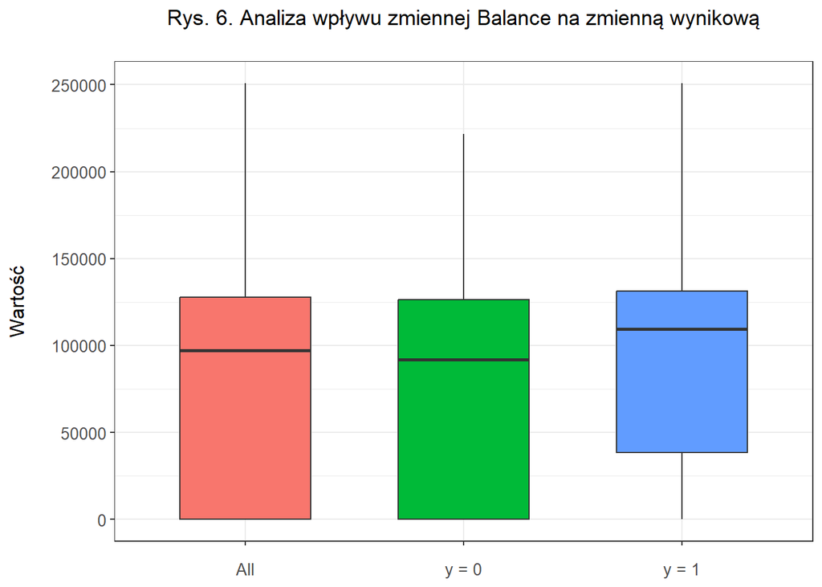

Tabela 5. Statystyki opisowe zmiennej Balance według wartości zmiennej wynikowej

|  | Średnia | Mediana | Min | Max | Odchylenie standardowe | Współczynnik zmienności | Skośność | Kurtoza |
| --- | --- | --- | --- | --- | --- | --- | --- | --- |
| All | 76485.89 | 97198.54 | 0 | 250898.1 | 62397.40 | 0.816 | -0.141 | -1.490 |
| y = 0 | 72745.30 | 92072.68 | 0 | 221532.8 | 62848.04 | 0.864 | -0.047 | -1.558 |
| y = 1 | 91108.54 | 109349.29 | 0 | 250898.1 | 58360.79 | 0.641 | -0.512 | -0.931 |

W przypadku zmiennej **`Balance`** wartość średniej arytmetycznej jest znacznie wyższa wśród klientów, którzy zdecydowali się opuścić bank, w porównaniu do tych, którzy pozostali. Wskazuje to na istotne różnice w saldach kont pomiędzy tymi dwiema grupami. Dolny kwartyl w grupie klientów, którzy odeszli, znajduje się wyraźnie wyżej, co sugeruje mniejszą liczbę niskich sald w tej grupie. Wynika z tego, że klienci z wyższym stanem konta częściej decydowali się na odejście, podczas gdy osoby z niższym saldem pozostawały w banku.

##### NumOfProducts

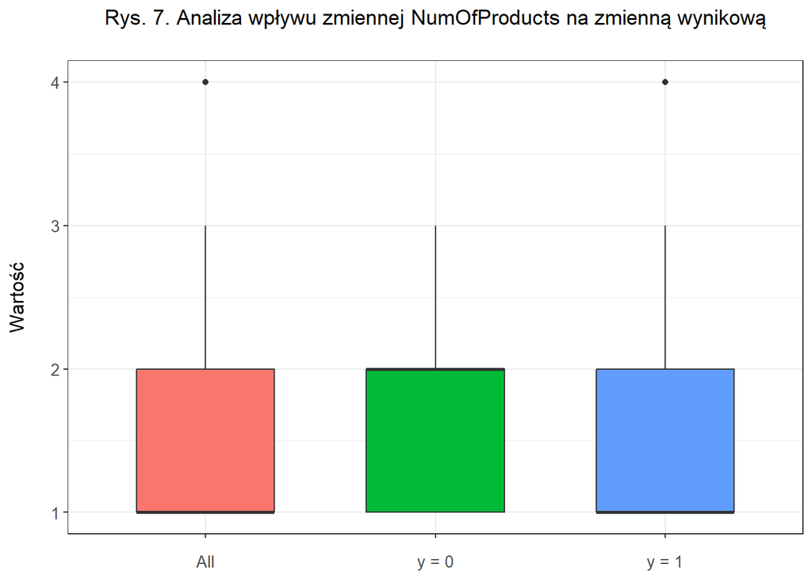

Tabela 6. Statystyki opisowe zmiennej NumOfProducts według wartości zmiennej wynikowej

|  | Średnia | Mediana | Min | Max | Odchylenie standardowe | Współczynnik zmienności | Skośność | Kurtoza |
| --- | --- | --- | --- | --- | --- | --- | --- | --- |
| All | 1.530 | 1 | 1 | 4 | 0.582 | 0.380 | 0.745 | 0.581 |
| y = 0 | 1.544 | 2 | 1 | 3 | 0.510 | 0.330 | -0.047 | -1.673 |
| y = 1 | 1.475 | 1 | 1 | 4 | 0.802 | 0.543 | 1.568 | 1.431 |

W odniesieniu do zmiennej **`NumOfProducts`** analiza wykresów pudełkowych oraz danych zawartych w tabeli 6 sugeruje, że zmienna ta ma niewielki wpływ na zmienną prognozowaną y. Średnie wartości w obu grupach są bardzo zbliżone, a zakresy wartości w dużym stopniu się pokrywają. Jednocześnie w grupie klientów, którzy odeszli z banku obserwuje się większe zróżnicowanie.

##### EstimatedSalary

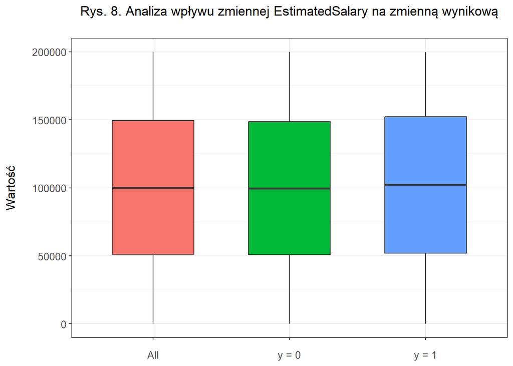

Tabela 7. Statystyki opisowe zmiennej EstimatedSalary według wartości zmiennej wynikowej

|  | Średnia | Mediana | Min | Max | Odchylenie standardowe | Współczynnik zmienności | Skośność | Kurtoza |
| --- | --- | --- | --- | --- | --- | --- | --- | --- |
| All | 100090.24 | 100193.91 | 11.58 | 199992.5 | 57510.49 | 0.575 | 0.002 | -1.182 |
| y = 0 | 99738.39 | 99645.04 | 90.07 | 199992.5 | 57405.59 | 0.576 | 0.011 | -1.173 |
| y = 1 | 101465.68 | 102460.84 | 11.58 | 199808.1 | 57912.42 | 0.571 | -0.033 | -1.214 |

Dla zmiennej **`EstimatedSalary`** można wnioskować o niewielkim wpływie tej zmiennej na odejście klientów z banku. Wartości mediany oraz średniej arytmetycznej są bardzo podobne, a rozkłady w znacznym stopniu się pokrywają.

#### 1.2.2. Analiza wpływu zmiennych kategorycznych

Po przeanalizowaniu wpływu zmiennych numerycznych na zmienną wynikową, przystąpiono do analizy zmiennych kategorycznych. W tym celu wykorzystano wykresy słupkowe z uwzględnieniem udziałów procentowych, aby móc precyzyjnie określić różnice w proporcjach pomiędzy poszczególnymi grupami.

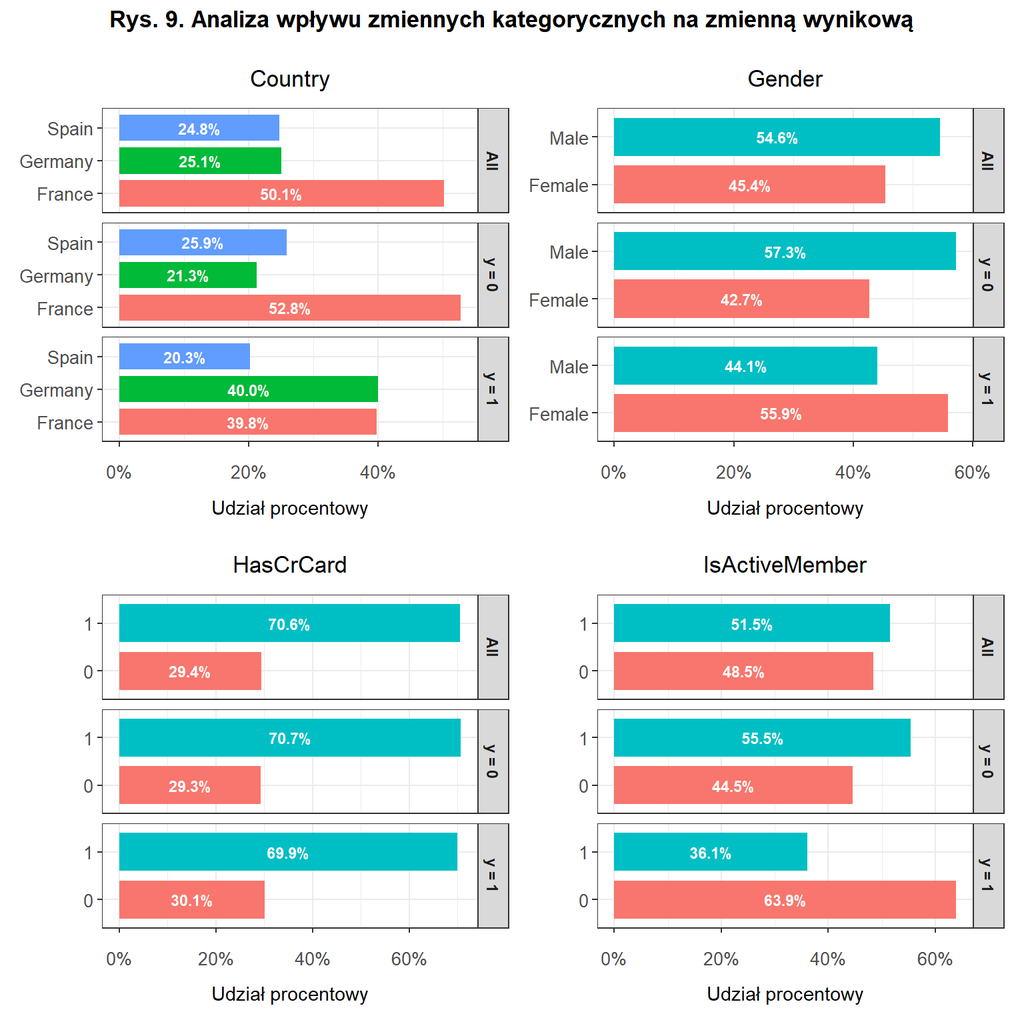

Wśród klientów decydujących się na pozostanie w banku, największą grupę według zmiennej **`Country`** stanowią mieszkańcy Francji, podczas gdy klienci z Hiszpanii oraz Niemiec reprezentują odpowiednio 25.9% i 21.3%. W przypadku klientów, którzy zrezygnowali z usług banku, największy udział mają klienci mieszkający w Niemczech (40%), następnie we Francji (39.8%) oraz Hiszpanii (20.3%). Wynika z tego, że klienci z Niemiec mogą mieć większą tendencję do odejścia z banku, gdyż ich udział w grupie klientów, którzy odeszli, znacząco wzrasta w porównaniu do ich udziału w grupie klientów, którzy pozostali w banku. Analiza zmiennej **`Gender`** wskazuje, że wśród osób pozostających w banku przeważają mężczyźni, stanowiący 57.3% tej grupy. Z kolei w grupie klientów, którzy zrezygnowali, dominują kobiety (55.9%), co może sugerować wyższą skłonność kobiet do odejścia z banku. Rozkład wartości zmiennej **`HasCrCard`** w każdym przypadku kształtuje się podobnie, stąd można wnioskować o niewielkim wpływie posiadania karty kredytowej na odejście klientów z banku. W przypadku zmiennej **`IsActiveMember`**, wśród klientów, którzy pozostali w banku większą część stanowią aktywni klienci (55.5%), natomiast wśród klientów, którzy zdecydowali się na odejście, dominują klienci rzadko korzystający z usług bankowych (63.9%). To sugeruje, że nieaktywni klienci są bardziej skłonni do rezygnacji.

### 1.3. Ocena zbalansowania zbioru danych

W celu oceny poziomu zbalansowania rozkładu zmiennej objaśnianej przeanalizowano liczebność obu klas, obliczając zarówno wartości bezwzględne, jak i procentowy udział każdej z nich w całej populacji. Uzyskane wyniki analizy zaprezentowano w poniższej tabeli.

Tabela 8. Analiza rozkładu zmiennej objaśnianej

| Wartość zmiennej wynikowej | Liczba obserwacji | Odsetek obserwacji [%] |
| --- | --- | --- |
| 0 | 7963 | 79.6 |
| 1 | 2037 | 20.4 |
| Razem | 10000 | 100.0 |

Na podstawie analizy powyższej tabeli można zauważyć, że zbiór danych jest niezbalansowany pod kątem zmiennej objaśnianej. Wartości “1” stanowią jedynie 20.4% całkowitego zbioru danych, podczas gdy wartości “0” osiągają 79.6%. Taka znaczna dysproporcja implikuje, iż model uczony na tym zestawie danych będzie wykazywał tendencję do faworyzowania klasy większościowej. W związku z tym, konieczne będzie zastosowanie metody resamplingu w celu zredukowania tego problemu.

## 2. Podział danych na zbiór uczący oraz testowy

Na potrzeby konstrukcji modeli klasyfikacyjnych oraz ich oceny, dokonano podziału danych na zbiory uczący oraz testowy. Wielkość zbioru uczącego ustalono na poziomie 80% wszystkich danych, a pozostałe obserwacje zakwalifikowano do zbioru testowego. Jako, że niektóre modele wymagają zastosowania kodowania one-hot coding, opracowano dwa rodzaje zestawów uczącego i testowego: jeden na danych oryginalnych oraz drugi na danych przekształconych przy użyciu one-hot coding.

Struktura danych po zastosowaniu one-hot coding przedstawia się następująco:

```
## 'data.frame':    10000 obs. of  12 variables:
##  $ CreditScore    : int  619 608 502 699 850 645 822 376 501 684 ...
##  $ Age            : int  42 41 42 39 43 44 50 29 44 27 ...
##  $ Tenure         : int  2 1 8 1 2 8 7 4 4 2 ...
##  $ Balance        : num  0 83808 159661 0 125511 ...
##  $ NumOfProducts  : int  1 1 3 2 1 2 2 4 2 1 ...
##  $ HasCrCard      : Factor w/ 2 levels "0","1": 2 1 2 1 2 2 2 2 1 2 ...
##  $ IsActiveMember : Factor w/ 2 levels "0","1": 2 2 1 1 2 1 2 1 2 2 ...
##  $ EstimatedSalary: num  101349 112543 113932 93827 79084 ...
##  $ Exited         : int  1 0 1 0 0 1 0 1 0 0 ...
##  $ Country.Germany: num  0 0 0 0 0 0 0 1 0 0 ...
##  $ Country.Spain  : num  0 1 0 0 1 1 0 0 0 0 ...
##  $ Gender.Male    : num  0 0 0 0 0 1 1 0 1 1 ...
```

Jak wspomniano wcześniej, dane charakteryzują się znacznym niezbalansowaniem, co wymaga zastosowania techniki resamplingu. Z uwagi na dużą liczbę obserwacji w badanym zestawie danych, zdecydowano się na zastosowanie undersamplingu, polegającemu na zmniejszeniu liczebności klasy większościowej do poziomu odpowiadającemu klasie mniejszościowej. Operacje przeprowadzono na zbiorach treningowych, obejmujących zarówno dane oryginalne, jak i te poddane procesowi one-hot coding.

Liczności klas zmiennej wynikowej w zbiorze uczącym po zastosowaniu undersamplingu na danych oryginalnych:

```
##
##    0    1
## 1608 1625
```

Liczności klas zmiennej wynikowej w zbiorze uczącym po zastosowaniu undersamplingu na danych po procesie one-hot coding:

```
##
##    0    1
## 1549 1629
```

Dodatkowo, z uwagi na to, że niektóre modele wymagają standaryzacji danych, utworzono odpowiednie zbiory uczące i testowe, zawierające zestandaryzowane zmienne numeryczne.

## 3. Implementacja modeli klasyfikacyjnych

W ramach niniejszego projektu zaimplementowano cztery modele klasyfikacyjne: KNN, regresję logistyczną, SVM oraz drzewa decyzyjne. Modele KNN, SVM i drzew decyzyjnych poddano optymalizacji hiperparametrów, natomiast w przypadku regresji logistycznej dokonano doboru punktu odcięcia. Modele zostały ocenione zarówno na zbiorze uczącym, jak i testowym w celu sprawdzenia, czy wystąpiło zjawisko przeuczenia.

### 3.1. Model KNN

**`Metoda k-najbliższych sąsiadów (KNN)`** działa w ten sposób, że dla każdego obiektu wyznacza k punktów o najmniejszej odległości od danego obiektu zgodnie z zadaną metryką, a następnie ustala dla tego obiektu wynik na postawie większości wyznaczonych obiektów (tzw. najbliższych sąsiadów). Parametr k w metodzie KNN reprezentuje liczbę sąsiadów, a optymalna wartość tego parametru powinna być określona poprzez budowę modeli dla różnych wartości k, a następnie wybór najlepszego modelu, to znaczy takiego, który posiada najwyższe wartości miar jakości klasyfikacji. Parametr k powinien być liczbą nieparzystą, aby uzyskać większość na rzecz którejś z wartości wyniku. W przypadku parzystej liczby sąsiadów może wystąpić remis, a wówczas program losowo wybierze wartość wyniku dla rozważanego obiektu.

#### 3.1.1. Budowa modeli

W przypadku zastosowania metody k-najbliższych sąsiadów wymagane jest przeprowadzenie standaryzacji danych, ponieważ metoda ta opiera się na wyznaczaniu odległości pomiędzy punktami. W związku z tym, różne skale zmiennych spowodowałyby zdominowanie odległości w znacznej mierze przez zmienne o dużym zakresie. Choć metoda KNN dopuszcza wykorzystanie zmiennych kategorycznych, konieczne jest ich wcześniejsze przekształcenie do postaci numerycznej, nadając im rangi lub konwertując na odpowiednią liczbę zmiennych binarnych.

Modele opracowano dla kilku wartości parametru k: 3, 5, 7, 9 oraz 11. Do analizy zdecydowano się na rozważanie wyłącznie nieparzystej liczby sąsiadów, aby zminimalizować ryzyko wystąpienia możliwego remisu podczas podejmowania decyzji klasyfikacyjnej.

#### 3.1.2. Ocena jakości klasyfikacji

Ocena jakości klasyfikacji w opracowanych modelach k-najbliższych sąsiadów została przeprowadzona za pomocą macierzy pomyłek, na podstawie której obliczono wartości miar czułości, dokładności oraz specyficzności. Wspomniane miary zostały obliczone zarówno dla wyników predykcji na zbiorze uczącym, jak i testowym. Uzyskane wyniki dla różnych wartości parametru k zestawiono w poniższej tabeli, uwzględniając dodatkowo kolumnę zawierającą średnią wartość miar jakości klasyfikacji na zbiorze testowym, która pozwoliła na porównanie modeli oraz wyłonienie optymalnej liczby sąsiadów.

Tabela 9. Porównanie jakości klasyfikacji modeli w zależności od wartości parametru k

| Parametr k | Zbiór uczący Dokładność | Zbiór uczący Czułość | Zbiór uczący Specyficzność | Zbiór testowy Dokładność | Zbiór testowy Czułość | Zbiór testowy Specyficzność | Zbiór testowy Średnia miar |
| --- | --- | --- | --- | --- | --- | --- | --- |
| 3 | 0.8578 | 0.8576 | 0.8580 | 0.7090 | 0.7598 | 0.6960 | 0.7216 |
| 5 | 0.8295 | 0.8214 | 0.8380 | 0.7215 | 0.7745 | 0.7079 | 0.7346 |
| 7 | 0.8090 | 0.8005 | 0.8179 | 0.7340 | 0.7843 | 0.7211 | 0.7465 |
| 9 | 0.8065 | 0.7962 | 0.8173 | 0.7315 | 0.7721 | 0.7211 | 0.7416 |
| 11 | 0.7930 | 0.7901 | 0.7960 | 0.7295 | 0.7721 | 0.7186 | 0.7401 |

Analiza wartości miar jakości klasyfikacji dla modelu KNN umożliwia jednoznaczne określenie parametru k, dla którego uzyskiwane są najlepsze wyniki. Dla zbioru uczącego najwyższe wartości wskaźników osiąga model przy trzech sąsiadach, natomiast wraz ze wzrostem ich liczby obserwuje się stopniowe pogorszenie rezultatów. W przypadku zbioru testowego wartości miar rosną do momentu osiągnięcia k = 7, po czym zaczynają maleć. W związku z powyższym, biorąc pod uwagę wyniki uzyskane na zbiorze testowym, za optymalną wartość parametru k należy uznać 7, ponieważ zapewnia ona najwyższą jakość klasyfikacji.

### 3.2. Regresja logistyczna

**`Regresja logistyczna`** stanowi rozszerzenie regresji liniowej, dostosowane do analizy problemów klasyfikacyjnych, gdzie zmienna zależna ma charakter binarny, co oznacza, że przyjmuje tylko dwie możliwe wartości. Zazwyczaj odnosi się do to wystąpienia lub braku określonego zjawiska. Metoda ta umożliwia oszacowanie prawdopodobieństwa przynależności danej obserwacji do jednej z kategorii zmiennej zależnej na podstawie wartości zmiennych objaśniających, które mogą być zarówno ilościowe, jak i kategoryczne. W przypadku zmiennych jakościowych niezbędne jest ich wcześniejsze przekształcenie do postaci binarnej, aby mogły zostać poprawnie uwzględnione w modelu. W środowisku R można to osiągnąć automatycznie za pomocą funkcji glm().

#### 3.2.1. Budowa modelu

Na podstawie przygotowanego zestawu danych treningowych opracowano model regresji logistycznej, który pozwala ocenić wpływ poszczególnych zmiennych objaśniających na prawdopodobieństwo odejścia klienta z banku. Poniżej przedstawiono wyniki estymacji parametrów wraz z ich istotnością statystyczną.

```
##
## Call:
## glm(formula = Exited ~ ., family = "binomial", data = training_set)
##
## Coefficients:
##                   Estimate Std. Error z value Pr(>|z|)
## (Intercept)     -2.667e+00  3.695e-01  -7.219 5.24e-13 ***
## CreditScore     -1.979e-04  4.123e-04  -0.480  0.63127
## CountryGermany   8.285e-01  1.019e-01   8.130 4.30e-16 ***
## CountrySpain     4.339e-02  1.024e-01   0.424  0.67182
## GenderMale      -5.744e-01  8.055e-02  -7.131 9.98e-13 ***
## Age              8.160e-02  4.293e-03  19.008  < 2e-16 ***
## Tenure          -1.998e-02  1.385e-02  -1.442  0.14925
## Balance          2.110e-06  7.262e-07   2.906  0.00367 **
## NumOfProducts   -7.128e-02  6.091e-02  -1.170  0.24189
## HasCrCard1      -2.236e-02  8.880e-02  -0.252  0.80116
## IsActiveMember1 -1.071e+00  8.191e-02 -13.072  < 2e-16 ***
## EstimatedSalary  4.220e-07  7.034e-07   0.600  0.54856
## ---
## Signif. codes:  0 '***' 0.001 '**' 0.01 '*' 0.05 '.' 0.1 ' ' 1
##
## (Dispersion parameter for binomial family taken to be 1)
##
##     Null deviance: 4481.8  on 3232  degrees of freedom
## Residual deviance: 3667.2  on 3221  degrees of freedom
## AIC: 3691.2
##
## Number of Fisher Scoring iterations: 4
```

Analiza wyników wskazuje, że jedynie część zmiennych niezależnych wykazuje statystycznie istotny wpływ na zmienną objaśnianą. Do czynników mających znaczenie w kwestii prawdopodobieństwa odejścia klienta należą: kraj zamieszkania, płeć, wiek, stan konta oraz to, czy klient jest aktywnym użytkownikiem. W przypadku zmiennych kategorycznych, pominięto jeden z poziomów, przyjmując go jako kategorię referencyjną, czyli punkt odniesienia, względem którego określany jest wpływ pozostałych kategorii danej zmiennej na odejście klienta z banku. W celu ułatwienia interpretacji oszacowanych parametrów modelu, przekształcono je za pomocą funkcji wykładniczej do postaci $\small e^{\beta}$. Wówczas w interpretacji korzysta się z tzw. **`ilorazu szans (ang. odd-ratio, OR).`**

Tabela 10. Wyniki estymacji parametrów dla modelu regresji logistycznej

| Zmienna | Współczynnik (β) | Iloraz szans (exp(β)) |
| --- | --- | --- |
| (Intercept) | -2.6674375 | 0.0694299 |
| CreditScore | -0.0001979 | 0.9998021 |
| CountryGermany | 0.8284668 | 2.2898053 |
| CountrySpain | 0.0433896 | 1.0443447 |
| GenderMale | -0.5743976 | 0.5630439 |
| Age | 0.0815998 | 1.0850215 |
| Tenure | -0.0199808 | 0.9802175 |
| Balance | 0.0000021 | 1.0000021 |
| NumOfProducts | -0.0712802 | 0.9312010 |
| HasCrCard1 | -0.0223633 | 0.9778849 |
| IsActiveMember1 | -1.0707091 | 0.3427654 |
| EstimatedSalary | 0.0000004 | 1.0000004 |

Interpretacja uzyskanych wartości uzyskanych dla poszczególnych zmiennych jest następująca:

- wartość parametru przy zmiennej **`CreditScore`** wynosi -0.0001979, co odpowiada ilorazowi szans 0.9998021. Ponadto współczynnik ten nie jest istotny statystycznie, co oznacza brak podstaw do stwierdzenia istotnego wpływu tej zmiennej na odejście klienta z banku
- wartość parametru przy zmiennej **`CountryGermany`** wynosi 0.8284668, co odpowiada ilorazowi szans 2.2898053. Oznacza to, że osoby mieszkające w Niemczech mają około 2.29 razy większe szanse odejścia z banku w porównaniu do osób z kategorii referencyjnej, czyli mieszkających we Francji, przy założeniu, że pozostałe zmienne pozostają niezmienione
- wartość parametru przy zmiennej **`CountrySpain`** wynosi 0.0433896, co odpowiada ilorazowi szans 1.0443447. Współczynnik nie jest istotny statystycznie, co oznacza brak podstaw do stwierdzenia wpływu pochodzenia klienta z Hiszpanii na odejście klienta z banku
- wartość parametru przy zmiennej **`GenderMale`** wynosi -0.5743976, co odpowiada ilorazowi szans 0.5630439. Oznacza to, że mężczyźni mają około 44% mniejsze szanse odejścia z banku w porównaniu do kobiet, przy założeniu niezmienności pozostałych zmiennych
- wartość parametru przy zmiennej **`Age`** wynosi 0.0815998, co odpowiada ilorazowi szans 1.0850215. Wskazuje to, że każdy dodatkowy rok życia zwiększa szanse odejścia klienta o około 8.5%, przy założeniu, że pozostałe zmienne pozostają niezmienione
- wartość parametru przy zmiennej **`Tenure`** wynosi -0.0199808, co odpowiada ilorazowi szans 0.9802175. Współczynnik ten nie jest istotny statystycznie, co oznacza brak podstaw do stwierdzenia wpływu długości bycia klientem banku na decyzję odnośnie odejścia
- wartość parametru przy zmiennej **`Balance`** wynosi 0.0000021, co odpowiada ilorazowi szans 1.0000021. Oznacza to, że stan konta klienta nie ma praktycznie żadnego wpływu na szanse odejścia klienta z banku
- wartość parametru przy zmiennej **`NumOfProducts`** wynosi -0.0712802, co odpowiada ilorazowi szans 0.9312010. Współczynnik przy tej zmiennej nie jest istotny statystycznie, co oznacza brak podstaw do stwierdzenia wpływu liczby produktów bankowych, z których korzysta klient, na jego odejście
- wartość parametru przy zmiennej **`HasCrCard1`** wynosi -0.0223633, co odpowiada ilorazowi szans 0.9778849. Współczynnik ten nie jest istotny statystycznie, co oznacza brak podstaw do stwierdzenia wpływu posiadania karty kredytowej na odejście klienta
- wartość parametru przy zmiennej **`IsActiveMember1`** wynosi -1.0707091, co odpowiada ilorazowi szans 0.3427654. Oznacza to, że bycie aktywnym użytkownikiem zmniejsza szanse odejścia klienta z banku aż o około 66%, przy założeniu, że pozostałe zmienne pozostają niezmienione
- wartość parametru przy zmiennej **`EstimatedSalary`** wynosi 0.0000004, co odpowiada ilorazowi szans 1.0000004. Dodatkowo, współczynnik przy tej zmiennej nie jest istotny statystycznie, co oznacza brak podstaw do stwierdzenia istotnego wpływu szacowanego rocznego wynagrodzenia klienta na jego odejście z banku

#### 3.2.2. Ocena jakości klasyfikacji

Model regresji logistycznej generuje przewidywane prawdopodobieństwa przynależności do danej klasy, dlatego konieczne jest przyjęcie punktu odcięcia, powyżej którego obserwacja klasyfikowana jest jako pozytywna (1), a poniżej którego jako negatywna (0). Aby wyznaczyć najbardziej adekwatny próg odcięcia, model przetestowano dla różnych wartości progu w zakresie od 0.4 do 0.7, z przyrostem co 0.05. Uzyskane wartości miar jakości klasyfikacji przedstawiono w poniższej tabeli (zob. Tabela 11). Analogicznie jak w przypadku modelu KNN, dodano kolumnę zawierającą średnią wartość miar jakości klasyfikacji na zbiorze testowym, która pozwoliła na porównanie modeli pod kątem wszystkich miar jednocześnie oraz wyłonienie optymalnej wartości progu odcięcia.

Tabela 11. Porównanie jakości klasyfikacji modeli w zależności od wartości progu odcięcia

| Próg odcięcia | Zbiór uczący Dokładność | Zbiór uczący Czułość | Zbiór uczący Specyficzność | Zbiór testowy Dokładność | Zbiór testowy Czułość | Zbiór testowy Specyficzność | Zbiór testowy Średnia miar |
| --- | --- | --- | --- | --- | --- | --- | --- |
| 0.40 | 0.7028 | 0.8234 | 0.5808 | 0.6155 | 0.8083 | 0.5655 | 0.6631 |
| 0.45 | 0.7099 | 0.7680 | 0.6511 | 0.6580 | 0.7597 | 0.6316 | 0.6831 |
| 0.50 | 0.7133 | 0.7077 | 0.7189 | 0.6995 | 0.6723 | 0.7065 | 0.6928 |
| 0.55 | 0.7083 | 0.6443 | 0.7730 | 0.7335 | 0.6068 | 0.7664 | 0.7022 |
| 0.60 | 0.6987 | 0.5680 | 0.8308 | 0.7595 | 0.5243 | 0.8205 | 0.7014 |
| 0.65 | 0.6842 | 0.4923 | 0.8781 | 0.7800 | 0.4515 | 0.8652 | 0.6989 |
| 0.70 | 0.6616 | 0.4148 | 0.9111 | 0.7895 | 0.3738 | 0.8974 | 0.6869 |

Na podstawie uzyskanych wyników można zaobserwować, że wraz ze zwiększaniem wartości punktu odcięcia na zbiorze testowym, zarówno dokładność, jak i specyficzność modelu ulegają poprawie, natomiast jednocześnie następuje znaczny spadek czułości. Oznacza to, że model coraz rzadziej identyfikuje klientów rzeczywiście zagrożonych odejściem z banku. W konsekwencji, nie istnieje jeden uniwersalny punkt odcięcia, który maksymalizowałby jednocześnie wszystkie miary jakości klasyfikacji. Wybór optymalnego punktu odcięcia powinien zatem stanowić kompromis pomiędzy czułością a specyficznością. W sytuacji, gdy bank preferuje wyższą czułość, nawet kosztem większej liczby klientów zakwalifikowanych fałszywie, jako ci, którzy planują odejście, zasadne jest ustalenie niższego progu odcięcia. Z kolei, jeżeli celem banku jest zwiększenie precyzji identyfikacji klientów zagrożonych odejściem, można rozważyć zastosowanie wyższego punktu odcięcia. Ponadto, wyniki uzyskane na zbiorze testowym nie odbiegają znacząco od rezultatów otrzymanych na zbiorze uczącym, co sugeruje brak przeuczenia modelu. Uwzględniając powyższe aspekty, podjęto decyzję o wyborze progu na poziomie 0.55, który pozwolił na uzyskanie najwyższej średniej wartości wszystkich miar.

Do oceny modeli regresji logistycznej możliwe jest również zastosowanie **`krzywej ROC`**. Ilustruje ona związek pomiędzy czułością a specyficznością danego modelu. Im bardziej wypukła jest krzywa, tym lepsza jest skuteczność modelu, dlatego najbardziej pożądana jest krzywa, która przylega do górnej lewej krawędzi tzn. współczynnik wyników prawdziwie pozytywnych jest bliski wartości 1, natomiast współczynnik wyników fałszywie pozytywnych zbliżony do 0. Dodatkowo oblicza się **`wartość AUC (ang. Area Under Curve),`** która reprezentuje pole znajdujące się pod krzywą ROC. Wartość ta wskazuje na prawdopodobieństwo, z jakim klasyfikator jest w stanie poprawnie rozróżnić losowo wybrany przypadek pozytywny od negatywnego.

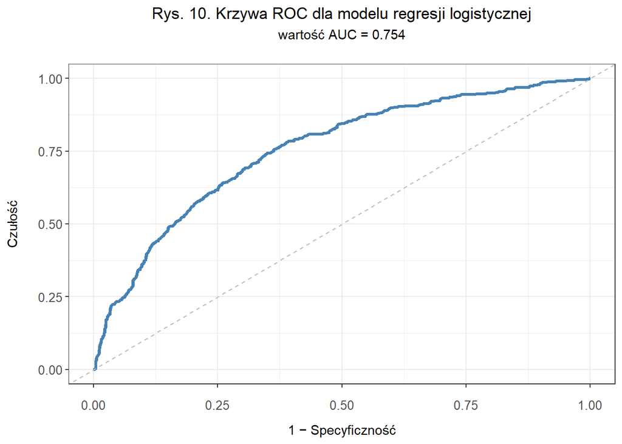

Krzywa ROC dla opracowanego modelu regresji logistycznej znajduje się w przybliżeniu w centralnej części wykresu, pomiędzy przekątną, która reprezentuje działanie klasyfikatora losowego, a lewą oraz górną krawędzią, wskazującą na model idealny. Można z tego wnioskować, że rozpatrywany model nie jest idealny, jednakże znacznie przewyższa efektywność klasyfikatora losowego. Wartość AUC dla opracowanego modelu regresji logistycznej wyniosła 0.754, co sugeruje, że klasyfikator poprawnie rozróżnia losowo wybrany przypadek pozytywny od negatywnego z prawdopodobieństwem 75%, co jest wynikiem satysfakcjonującym.

### 3.3. Model SVM

**`Maszyna wektorów nośnych (ang. Support Vector Machine, SVM)`** jest zaawansowaną metodą uczenia maszynowego, stosowaną głównie w kontekście zadań klasyfikacyjnych. Jej celem jest ustalenie optymalnej granicy decyzyjnej, która oddziela obserwacje przynależące do różnych klas. W zależności od charakterystyki danych, granica ta może przybierać formę liniową lub nieliniową, co umożliwia elastyczne dostosowanie modelu do struktury przestrzeni cech. Z uwagi na to, iż dane rzeczywiste rzadko są liniowo separowalne, algorytm SVM wykorzystuje tzw. sztuczki jądrowe (ang. kernel tricks), co pozwala na efektywną klasyfikację nieliniową poprzez transformację przestrzeni cech. W tym kontekście najczęściej stosowanymi funkcjami jądrowymi są jądra wielomianowe oraz radialne.

#### 3.3.1. Budowa modeli

Algorytm SVM wymaga, aby dane były standaryzowane, natomiast zmienne kategoryczne reprezentowane w formacie binarnym, co wiąże się z koniecznością zastosowania zestawów danych z uwzględnieniem procesu one-hot coding. W kontekście maszyn wektorów nośnych, szczególną uwagę należy zwrócić na optymalizację hiperparametrów, takich jak typ jądra, parametr kosztu, stopień wielomianu oraz gamma.

W analizie zastosowano następujące wartości hiperparametrów:

- typ jądra: liniowe, radialne, wielomianowe
- parametr kosztu: 0.5, 1, 5
- stopień wielomianu: 2, 3
- gamma: 0.05, 0.1, 0.5

Dla każdej kombinacji wspomnianych wyżej parametrów wytrenowano model maszyny wektorów nośnych.

#### 3.3.2. Ocena jakości klasyfikacji

W celu oceny skuteczności klasyfikacji, obliczono podstawowe miary jakości predykcji tj. dokładność, czułość oraz specyficzność dla każdej z kombinacji wspomnianych w poprzednim podrozdziale parametrów. Zestawienie uzyskanych wyników przedstawiono poniżej, porządkując je malejąco według średniej wartości wszystkich trzech miar jakości klasyfikacji na zbiorze testowym. Aby poprawić czytelność tabeli oraz ograniczyć jej szerokość, nazwy typów jąder zostały skrócone do ich pierwszych liter: L, R oraz W.

| Typ jądra | Koszt | Stopień | Gamma | Zbiór uczący Dokładność | Zbiór uczący Czułość | Zbiór uczący Specyficzność | Zbiór testowy Dokładność | Zbiór testowy Czułość | Zbiór testowy Specyficzność | Zbiór testowy Średnia miar |
| --- | --- | --- | --- | --- | --- | --- | --- | --- | --- | --- |
| W | 5 | 3 | 0.05 | 0.804 | 0.7888 | 0.8199 | 0.748 | 0.8015 | 0.7343 | 0.7613 |
| W | 1 | 3 | 0.1 | 0.8081 | 0.7974 | 0.8192 | 0.7455 | 0.7966 | 0.7324 | 0.7582 |
| W | 0.5 | 3 | 0.1 | 0.804 | 0.7894 | 0.8192 | 0.7435 | 0.8015 | 0.7286 | 0.7579 |
| W | 0.5 | 3 | 0.5 | 0.8213 | 0.8109 | 0.8321 | 0.743 | 0.799 | 0.7286 | 0.7569 |
| W | 5 | 3 | 0.1 | 0.8131 | 0.8066 | 0.8199 | 0.7435 | 0.7941 | 0.7305 | 0.756 |
| W | 5 | 3 | 0.5 | 0.826 | 0.814 | 0.8386 | 0.7385 | 0.8015 | 0.7224 | 0.7541 |
| W | 1 | 3 | 0.5 | 0.8272 | 0.8177 | 0.8373 | 0.7385 | 0.7917 | 0.7249 | 0.7517 |
| R | 5 | – | 0.1 | 0.8402 | 0.8263 | 0.8547 | 0.73 | 0.8137 | 0.7085 | 0.7507 |
| R | 5 | – | 0.05 | 0.809 | 0.7901 | 0.8289 | 0.7295 | 0.8113 | 0.7085 | 0.7498 |
| R | 1 | – | 0.1 | 0.8118 | 0.798 | 0.8263 | 0.726 | 0.8137 | 0.7035 | 0.7477 |
| R | 0.5 | – | 0.1 | 0.7992 | 0.7845 | 0.8147 | 0.7205 | 0.826 | 0.6935 | 0.7467 |
| W | 5 | 2 | 0.1 | 0.7804 | 0.7526 | 0.8096 | 0.7175 | 0.8284 | 0.6891 | 0.745 |
| W | 5 | 2 | 0.05 | 0.7738 | 0.7532 | 0.7954 | 0.7135 | 0.8333 | 0.6828 | 0.7432 |
| W | 1 | 3 | 0.05 | 0.7895 | 0.7735 | 0.8063 | 0.7205 | 0.8088 | 0.6979 | 0.7424 |
| R | 1 | – | 0.05 | 0.7948 | 0.7747 | 0.816 | 0.7155 | 0.8235 | 0.6878 | 0.7423 |
| W | 0.5 | 2 | 0.5 | 0.781 | 0.7545 | 0.8089 | 0.7155 | 0.8235 | 0.6878 | 0.7423 |
| W | 1 | 2 | 0.1 | 0.775 | 0.7581 | 0.7928 | 0.7125 | 0.8309 | 0.6822 | 0.7419 |
| W | 5 | 2 | 0.5 | 0.7813 | 0.7514 | 0.8128 | 0.713 | 0.8186 | 0.6859 | 0.7392 |
| R | 0.5 | – | 0.05 | 0.7819 | 0.763 | 0.8018 | 0.708 | 0.8333 | 0.6759 | 0.7391 |
| W | 0.5 | 2 | 0.1 | 0.7772 | 0.7686 | 0.7863 | 0.704 | 0.8456 | 0.6677 | 0.7391 |
| W | 1 | 2 | 0.5 | 0.7807 | 0.7526 | 0.8102 | 0.713 | 0.8137 | 0.6872 | 0.738 |
| R | 1 | – | 0.5 | 0.9132 | 0.911 | 0.9154 | 0.7115 | 0.8015 | 0.6884 | 0.7338 |
| R | 0.5 | – | 0.5 | 0.8754 | 0.8864 | 0.8638 | 0.7005 | 0.8284 | 0.6677 | 0.7322 |
| W | 1 | 2 | 0.05 | 0.7813 | 0.7851 | 0.7773 | 0.6905 | 0.848 | 0.6501 | 0.7295 |
| W | 0.5 | 3 | 0.05 | 0.7797 | 0.7673 | 0.7928 | 0.7065 | 0.799 | 0.6828 | 0.7294 |
| W | 0.5 | 2 | 0.05 | 0.775 | 0.7888 | 0.7605 | 0.664 | 0.8358 | 0.62 | 0.7066 |
| R | 5 | – | 0.5 | 0.9811 | 0.9822 | 0.98 | 0.677 | 0.7819 | 0.6501 | 0.703 |
| L | 0.5 | – | – | 0.7149 | 0.7145 | 0.7153 | 0.6625 | 0.7647 | 0.6363 | 0.6878 |
| L | 1 | – | – | 0.714 | 0.7139 | 0.714 | 0.6615 | 0.7647 | 0.6351 | 0.6871 |
| L | 5 | – | – | 0.7137 | 0.7139 | 0.7134 | 0.6615 | 0.7647 | 0.6351 | 0.6871 |

### 3.4. Drzewa decyzyjne

**`Drzewa decyzyjne`** to metoda uczenia maszynowego, która znajduje zastosowanie zarówno w klasyfikacji, jak i regresji. Metoda ta polega na iteracyjnym dzieleniu danych na coraz mniejsze podzbiory, opierając się na wartościach zmiennych predykcyjnych. Każdy węzeł drzewa symbolizuje kryterium decyzyjne, natomiast końcowe liście zawierają przewidywaną klasę lub wartość zmiennej ciągłej. Drzewa decyzyjne są szczególnie cenione za swoją intuicyjność w interpretacji oraz możliwość wizualizacji procesu podejmowania decyzji.

#### 3.4.1. Budowa modelu

W pierwszej kolejności utworzono największe możliwe drzewo decyzyjne bez ustalania maksymalnej głębokości, a następnie przedstawiono je za pomocą wizualizacji.

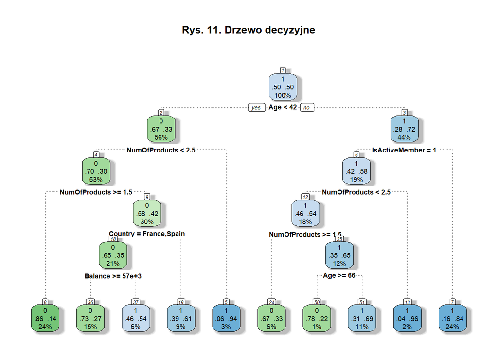

Drzewo decyzyjne interpretowane jest poprzez rozpoczęcie od węzła głównego, a następnie przechodzenie przez kolejne gałęzie zgodnie z warunkami podziału, aż do osiągnięcia coraz bardziej jednorodnych grup. W analizowanym modelu najważniejszym kryterium pierwszego podziału okazał się wiek klientów banku, reprezentowany przez zmienną **`Age`.** Klienci poniżej 42. roku życia, którzy stanowią 56% wszystkich obserwacji, są klasyfikowani z prawdopodobieństwem 33% jako osoby, które opuściły bank. Natomiast w grupie klientów starszych, aż 72% zaklasyfikowano jako tych, którzy odeszli z banku. W lewej części drzewa, obejmującej klientów poniżej 42. roku życia, gdzie dominują klienci pozostający w banku, kolejnym kryterium podziału jest liczba produktów bankowych, z jakich korzysta klient (**`NumOfProducts`**). Klienci korzystający z mniej niż 2.5 produktu, czyli jednego bądź dwóch produktów, są klasyfikowani z prawdopodobieństwem 30% jako osoby, które opuściły bank. W obrębie tej grupy dokonano kolejnych podziałów według liczby produktów, kraju pochodzenia oraz stanu konta. Z kolei klienci korzystający z co najmniej trzech produktów zostali klasyfikowani jako osoby, które opuściły bank w 94% przypadków, tworząc tym samym końcową podgrupę. Jeśli chodzi o prawą gałąź drzewa, obejmującej klientów mających co najmniej 42 lata, dokonano podziału według aktywności użytkowników, a w kolejnych poziomach dwukrotnie według liczby produktów oraz ponownie według wieku. Ostatecznie uzyskano 10 podgrup, a głębokość drzewa wyniosła 5.

#### 3.4.2. Optymalizacja parametrów i ocena jakości klasyfikacji

W następnym etapie dokonano przycinania drzewa, testując wyniki dla różnych głębokości drzewa w zakresie od 2 do 5. Sprawdzono również zastosowanie alternatywnej reguły klasyfikacyjnej tj. indeksu entropii. W poniższej tabeli przedstawiono wartości miar jakości klasyfikacji zarówno na zbiorze uczącym, jak i testowym.

Tabela 12. Porównanie jakości klasyfikacji modeli w zależności od wartości parametrów

| Reguła | Głębokość | Zbiór uczący Dokładność | Zbiór uczący Czułość | Zbiór uczący Specyficzność | Zbiór testowy Dokładność | Zbiór testowy Czułość | Zbiór testowy Specyficzność | Zbiór testowy Średnia miar |
| --- | --- | --- | --- | --- | --- | --- | --- | --- |
| gini | 2 | 0.7167 | 0.6818 | 0.7519 | 0.7325 | 0.6820 | 0.7456 | 0.7200 |
| gini | 3 | 0.7167 | 0.6818 | 0.7519 | 0.7325 | 0.6820 | 0.7456 | 0.7200 |
| gini | 4 | 0.7560 | 0.7458 | 0.7662 | 0.7585 | 0.7209 | 0.7683 | 0.7492 |
| gini | 5 | 0.7668 | 0.8086 | 0.7245 | 0.7345 | 0.7670 | 0.7261 | 0.7425 |
| information | 2 | 0.7167 | 0.6818 | 0.7519 | 0.7325 | 0.6820 | 0.7456 | 0.7200 |
| information | 3 | 0.7167 | 0.6818 | 0.7519 | 0.7325 | 0.6820 | 0.7456 | 0.7200 |
| information | 4 | 0.7560 | 0.7458 | 0.7662 | 0.7585 | 0.7209 | 0.7683 | 0.7492 |
| information | 5 | 0.7612 | 0.8129 | 0.7090 | 0.7220 | 0.7694 | 0.7097 | 0.7337 |

Na podstawie analizy zawartości tabeli 12 można stwierdzić, że wybór reguły klasyfikacyjnej nie ma istotnego wpływu na uzyskiwane wyniki. Zauważalne są jedynie niewielkie róznice w wynikach przy głebokości równej 5. Reguła entropii wykazuje wyższą wartość czułości, natomiast reguła Giniego zapewnia wyższą dokładność oraz specyficzność. Analizując wyniki pod kątem głębokości drzewa, najwyższe wskazania czułości osiągnięto dla pełnego drzewa, jednakże przycięcie drzewa do głębokości 4 pozwala na uzyskanie wyższej dokładności i specyficzności. W związku z tym, wybór odpowiedniej głębokości drzewa zależy od potrzeb i preferencji banku, który chce przewidzieć odejście klienta. Jednakże, kierując się średnią wartością miar zdecydowano się na wybór głębokości 4. Reguła klasyfikacyjna w tym przypadku nie ma istotnego znaczenia, ponieważ obie osiągają identyczne wyniki na obranym poziomie dokładności. Jednocześnie warto zwrócić uwagę na podobieństwo wyników uzyskanych dla zbiorów uczącego oraz testowego, co wskazuje na brak wystąpienia zjawiska przeuczenia modelu.

Rysunek 12 przedstawia ważność zmiennych w modelach drzew decyzyjnych, które zostały opracowane z zastosowaniem optymalnych parametrów. Znaczenie poszczególnych zmienych ocenia się m.in. za pomocą wskaźnika Giniego, który mierzy, o ile zmniejsza się nieczystość węzłów drzewa decyzyjnego przy podziale danych według określonej cechy. Wyższa wartość wskaźnika oznacza większy wkład zmiennej w skuteczność prognozowania i pozwala wskazać naistotniejsze zmienne w modelu.

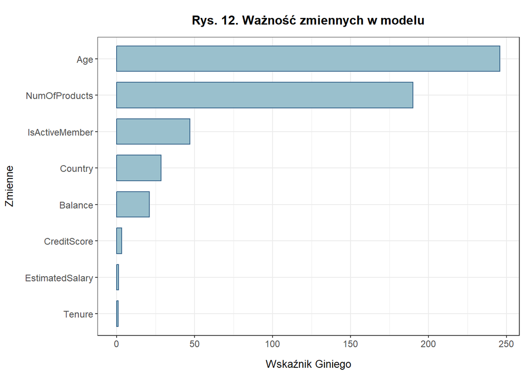

Analizując powyższą wizualizację, można stwierdzić, że zmienna **`Age`** posiada największą ważność, co sugeruje, że miała ona największy wpływ na decyzje podejmowane przez model. Następnie, na drugim miejscu znajduje się zmienna **`NumOfProducts`,** określająca liczbę produktów bankowych posiadanych przez klienta. Zmienna **`IsActiveMember`** wskazująca na aktywność użytkownika, oraz kraj zamieszkania (**`Country`**) mają w tym przypadku umiarkowane znaczenie. Zmienna opisująca stan konta (**`Balance`**) wykazuje nieco mniejszy, aczkolwiek nadal dostrzegalny wkład. W odniesieniu do pozostałych zmiennych ich wpływ jest praktycznie znikomy.

## 4. Analiza uzyskanych wyników

W ramach projektu przeprowadzono również porównanie jakości klasyfikacji rozważanych modeli. W poniższym zestawieniu uwzględniono te modele, które osiągnęły najwyższą średnią wartość wskaźników jakości klasyfikacji na zbiorze testowym i zostały wskazane jako najskuteczniejsze w kontekście predykcji w poprzednich analizach. Dla modelu KNN uwzględniona wartość parametru k to 7. W przypadku SVM zastosowane hiperparametry to: jądro wielomianowe, parametr kosztu równy 5, stopień wielomianu wynoszący 3 i parametr gamma o wartości 0.05. Dla modelu drzewa decyzyjnego ustalone parametry to maksymalna głębokość równa 4 oraz reguła podziału oparta na kryterium Giniego.

Tabela 13. Porównanie jakości klasyfikacji analizowanych modeli

| Model | Zbiór uczący Dokładność | Zbiór uczący Czułość | Zbiór uczący Specyficzność | Zbiór testowy Dokładność | Zbiór testowy Czułość | Zbiór testowy Specyficzność |
| --- | --- | --- | --- | --- | --- | --- |
| KNN | 0.8090 | 0.8005 | 0.8179 | 0.7340 | 0.7843 | 0.7211 |
| Regresja logistyczna | 0.7083 | 0.6443 | 0.7730 | 0.7335 | 0.6068 | 0.7664 |
| SVM | 0.8040 | 0.7888 | 0.8199 | 0.7480 | 0.8015 | 0.7343 |
| Drzewo decyzyjne | 0.7560 | 0.7458 | 0.7662 | 0.7585 | 0.7209 | 0.7683 |

Analiza wyników zestawionych w tabeli wskazuje, że model drzewa decyzyjnego osiągnął najwyższe wartości miar dokładności oraz specyficzności w porównaniu z innymi modelami. Z drugiej strony, najwyższą czułość wynoszącą 0.8015 odnotowano dla maszyny wektorów nośnych, co oznacza, że ten model najlepiej radzi sobie z wykrywaniem klasy pozytywnej. Model KNN osiągnął wyniki zbliżone do SVM pod względem czułości, jednak charakteryzował się niższą dokładnością oraz specyficznością. Regresja logistyczna wypadła najsłabiej w tym zestawieniu, uzyskując najniższe wyniki zarówno w zakresie dokładności, jak i czułości na zbiorze testowym. Wyniki te sugerują, iż drzewo decyzyjne stanowi najlepszy wybór pod względem ogólnej skuteczności predykcyjnej. Niemniej jednak, gdy priorytetem jest identyfikacja klasy pozytywnej, w tym przypadku klientów opuszczających bank, należy wskazać na model SVM.

## 5. Analiza interpretowalności

Interpretowalność modelu odnosi się do zdolności bycia zrozumianym przez człowieka, co oznacza logiczność podejmowanych przez model decyzji oraz prognoz. W projekcie zdecydowano się na przeprowadzenie analizy interpretowalności zbudowanego wcześniej modelu regresji logistycznej. Użyto w tym celu trzech narzędzi: profili ceteris-paribus, wykresów częściowej zależności oraz wartości SHAP.

### 5.1. Profile ceteris paribus

**`Profile ceteris-paribus`** obrazują, jak zmienia się predykcja modelu, jeśli wartość danej zmiennej objaśniającej dla badanej obserwacji ulegnie zmianie. Profil bazuje na jednej konkretnej obserwacji, dlatego wybrano ze zbioru uczącego pierwszego klienta, który odszedł z banku, a następnie przedstawiono w oparciu o niego wykresy dla każdej zmiennej objaśniającej.

```
##  CreditScore Country Gender Age Tenure  Balance NumOfProducts HasCrCard
##          502  France Female  42      8 159660.8             3         1
##  IsActiveMember EstimatedSalary Exited
##               0        113931.6      1
```

```
## Prawdopodobieństwo odejścia klienta wynosi: 0.657
```

Wybranym klientem jest 42-letnia kobieta, zamieszkała we Francji, ze zdolnością kredytową wynoszącą 502. Klientka ta jest związana z bankiem od ośmiu lat, a jej saldo konta wynosi 159660.8. Posiada trzy produkty bankowe oraz kartę kredytową, jednakże nie jest aktywnym użytkownikiem banku. Średnia roczna pensja tej klientki to 113931.6. Prawdopodobieństwo jej zakwalifikowania do grupy klientów, którzy odeszli z banku wynosi około 65.69%. Na poniższej wizualizacji przedstawiono profile ceteris-paribus dla zmiennych numerycznych w modelu regresji logistycznej, obliczone dla tej konkretnej obserwacji.

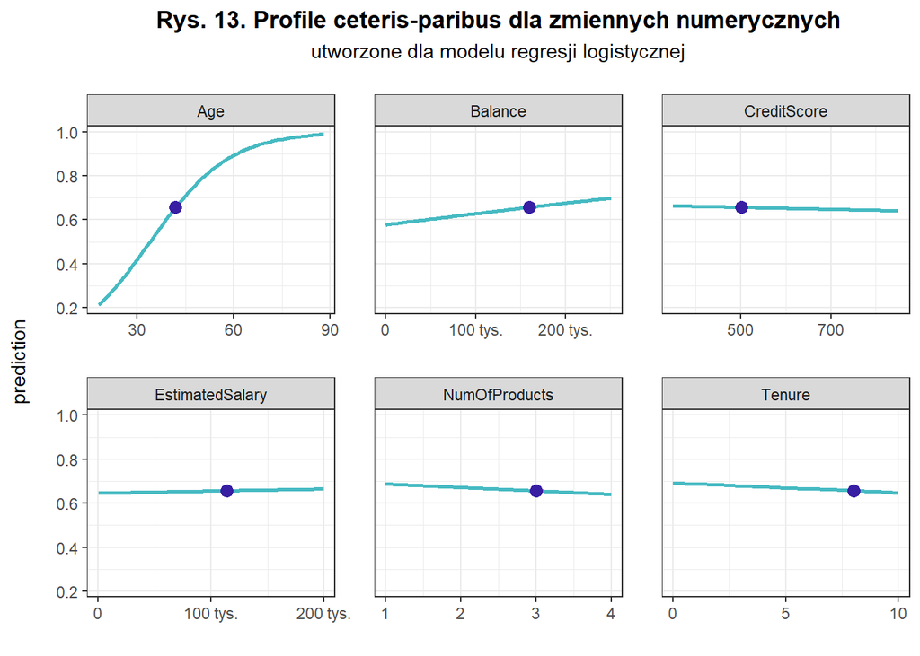

Profil ceteris-paribus dla zmiennej **`Age`** przyjmuje kształt zbliżony do krzywej logistycznej. Analiza krzywej, przeprowadzona na przykładzie wybranej klientki w wieku 42 lat, wskazuje, że w przypadku, gdyby była ona młodsza, prawdopodobieństwo opuszczenia banku byłoby zdecydowanie niższe. Natomiast jeśli byłaby starsza, wspomniane prawdopodobieństwo by znacznie wzrosło, choć ustabilizowałoby się po 70. roku życia. Pozostałe zmienne ilościowe mają stosunkowo niewielki wpływ na predykcję: zmienna **`Balance`** wykazuje nieznaczny wzrost, **`CreditScore`**, **`NumOfProducts`** oraz **`Tenure`** nieznacznie maleją, natomiast **`EstimatedSalary`** przedstawiona jest praktycznie w postaci linii prostej. Reasumując, w przypadku tej klientki wiek ma największy wpływ na przewidywane prawdopodobieństwo odejścia.

Następnie dla wybranej obserwacji opracowano profile ceteris-paribus dla zmiennych kategorycznych. Odpowiednie wykresy przedstawiono poniżej.

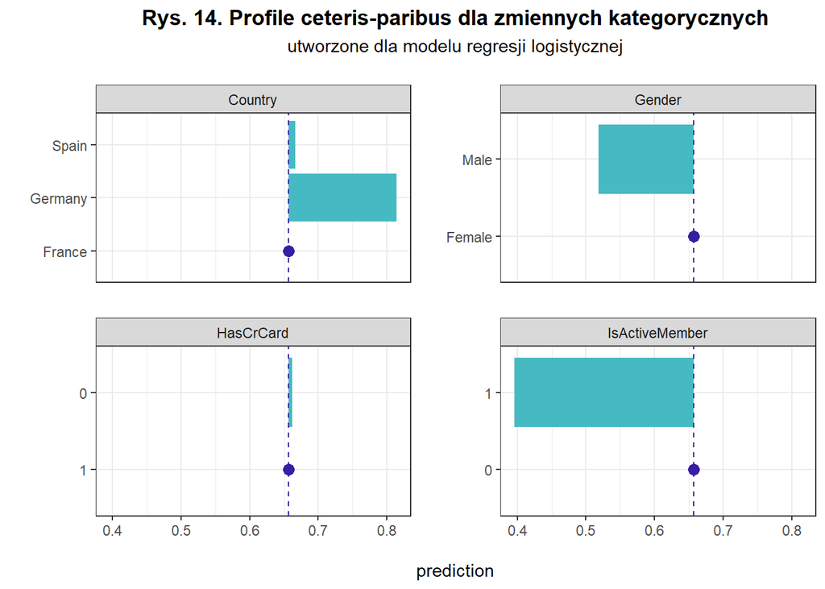

Analizując wpływ zmiennych kategorycznych, można zaobserwować znaczący wpływ zmiennych **`IsActiveMember`,** **`Country`** oraz **`Gender`.** W przypadku, gdyby wybrana klientka mieszkała w Niemczech, prawdopodobieństwo jej odejścia z banku wzrosłoby do ponad 80%, przy założeniu, że pozostałe zmienne pozostają niezmienione. Z kolei, gdyby mieszkała w Hiszpanii, prawdopodobieństwo również by wzrosło, aczkolwiek w bardzo ograniczonym zakresie. Istotny wpływ wykazała również płeć klientki. Gdyby była mężczyzną, prawdopodobieństwo jej odejścia z banku zmalałoby do około 54%. Największe znaczenie w tym kontekście miało jednak aktywne uczestnictwo w usługach bankowych. Gdyby klientka była aktywnym użytkownikiem, prawdopodobieństwo jej odejścia z banku wyniosłoby 40%, zakładając niezmienność pozostałych zmiennych. Należy zauważyć, że brak posiadania karty kredytowej nie miałby zauważalnego wpływu na decyzję klientki o odejściu z banku.

### 5.2. Wykresy częściowej zależności

**`Wykresy częściowej zależności (Partial Dependency Plots, PDP)`** ilustrują, w jaki sposób średnia prognoza modelu ulega zmianom w zależności od wartości jednej zmiennej, przy uśrednieniu pozostałych zmiennych predykcyjnych w całym zbiorze danych. W przeciwieństwie do modeli PCP, które koncentrują się na oddziaływaniu na poziomie pojedynczej obserwacji, modele PDP przedstawiają globalny wpływ zmiennej na wyniki modelu. Profil PD jest zatem obliczany jako średnia profilów CP dla wszystkich obserwacji w analizowanym zbiorze danych.

Poniżej przedstawiono wykresy ilustrujące wpływ wszystkich zmiennych numerycznych na analizowany model regresji logistycznej.

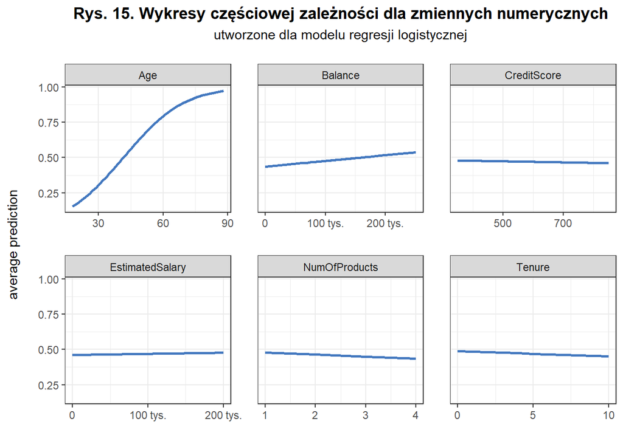

Można zauważyć, że przedstawione wykresy częściowej zależności wyglądają niemal identycznie, jak wykresy dla profilu ceteris-paribus. Oznacza to, że nie ma silnych interakcji pomiędzy zmiennymi objaśniającymi. Model jest stabilny, a wpływ zmiennych jest spójny zarówno w ujęciu lokalnym, jak i globalnym. Największy wpływ na decyzję klienta o odejściu z banku wykazuje zmienna **`Age`**, podczas gdy zmienne opisujące stan konta (**`Balance`**) oraz liczbę posiadanych produktów bankowych (**`NumOfProducts`**) stosunkowo niewielki. W przypadku pozostałych zmiennych wpływ należy uznać za znikomy.

W następnym kroku zbadano wpływ zmiennych kategorycznych na wyniki modelu regresji logistycznej. Stosowne wizualizacje zamieszczono na Rys. 16.

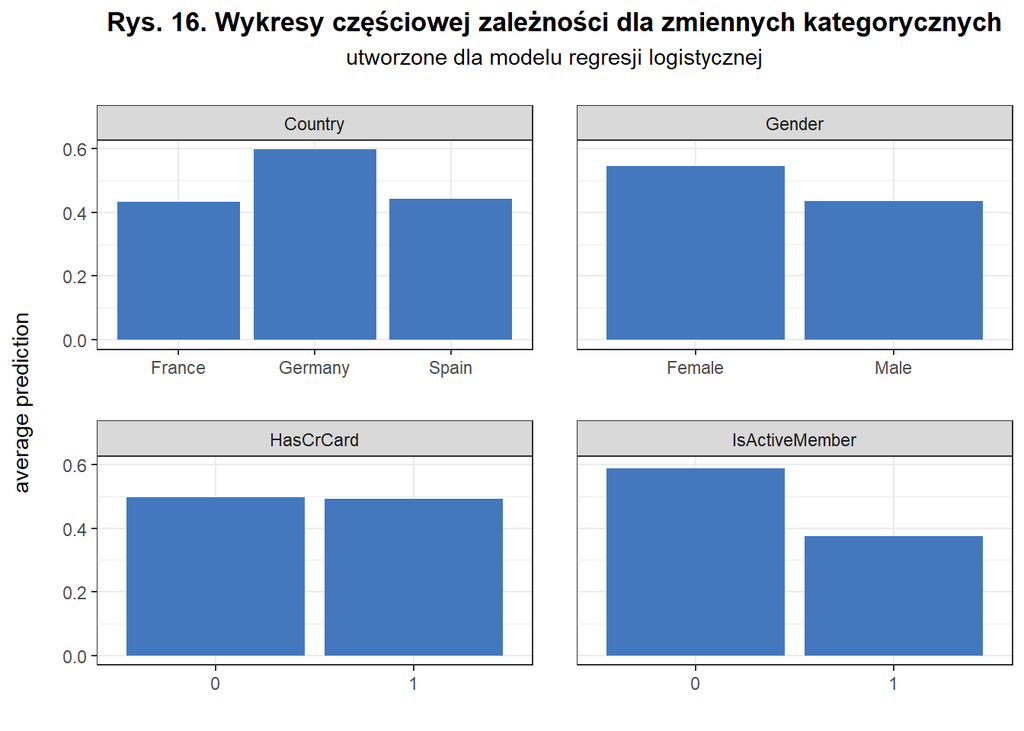

Wykresy częściowej zależności dają także możliwość łącznia zmiennych, co umożliwia przeanalizowanie ich wspólnego wpływu na zmienną objaśnianą. Z uwagi na to, że spośród zmiennych ilościowych zmienna **`Age`** wykazała największy wpływ, zdecydowano się połączyć ją ze zmiennymi kategorycznymi, a następnie przeanalizowano ich wspólny wpływ na podstawie wykresów (zob. Rys. 17).

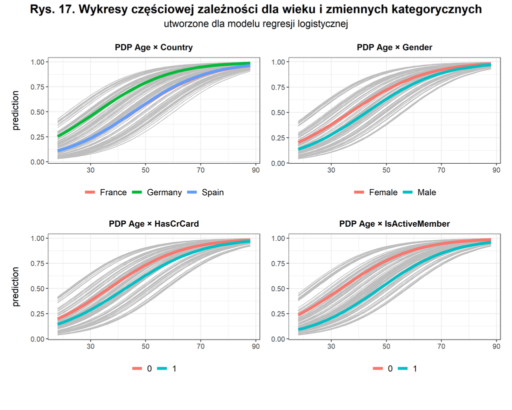

Dla każdego z analizowanych wykresów linie dla poszczególnych grup wykazują zbliżony kształt oraz przebiegają niemal równolegle. To wskazuje na brak istotnych interakcji między wiekiem a badanymi zmiennymi kategorycznymi. W konsekwencji, wpływ wieku na prognozy modelu jest zatem podobny w każdej grupie, co pokrywa się z wnioskami wyciągniętymi z analizy ich pojedynczego wpływu na model.

### 5.3. Wartości SHAP

**`Wartości SHAP (ang. SHapley Additive exPlanations)`** stanowią istotne narzędzie do oceny wpływu poszczególnych zmiennych na ostateczny rezultat. Wartości te są miarą, która określa, w jakim stopniu każda zmienna przyczynia się do predykcji modelu dla konkretnej obserwacji w odniesieniu do wartości bazowej, reprezentowanej przez średnią predykcję modelu, wyrażoną jako stała. Wykres, podobnie jak profil ceteris paribus, opiera się na jednej konkretnej obserwacji, w tym przypadku wybranej wcześniej klientki. W kontekście analizowanego modelu regresji logistycznej zaprezentowano wykres wartości SHAP dla tej klientki, uwzględniając wszystkie zmienne objaśniające, bez określania ich kolejności.

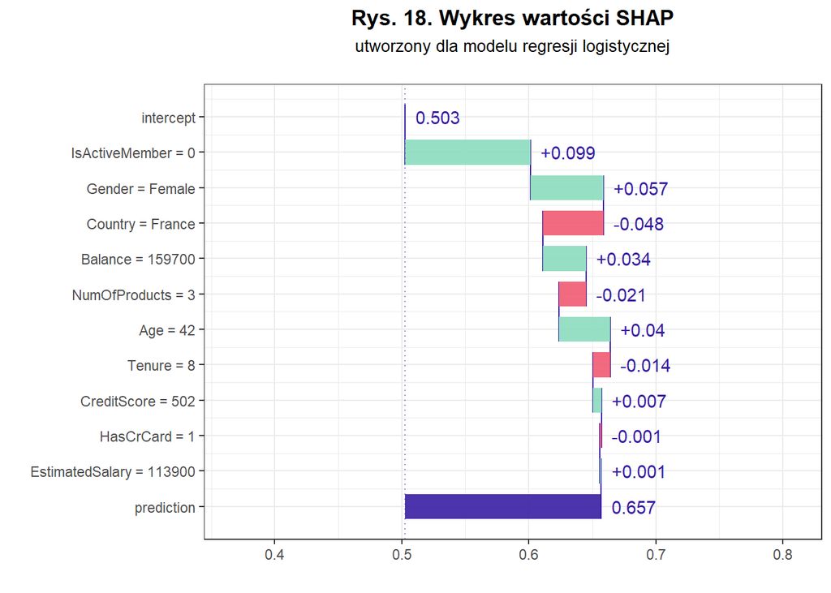

Z analizy przedstawionego wykresu wynika, że początkowo brak aktywności wybranej klientki jako użytkownika zwiększył jej prawdopodobieństwo odejścia o niemal 10 p.p.. Następnie, fakt, iż jest kobietą, podniósł to prawdopodobieństwo o kolejne 5.7 punktu procentowego. W przeciwnym kierunku oddziaływał fakt, że klientka mieszka we Francji, co zmniejszyło prawdopodobieństwo odejścia o 4.8 p.p.. Stan konta klientki przyczynił się do zwiększenia prawdopodobieństwa o 3.4 p.p., natomiast posiadanie trzech produktów bankowych obniżyło to prawdopodobieństwo o 2.1 p.p.. Wiek klientki, wynoszący 42 lata, ponownie zwiększył prawdopodobieństwo odejścia o 4 p.p., podczas gdy korzystanie z usług banku przez 8 lat zmniejszyło to prawdopodobieństwo o 1.4 punktu procentowego. Proces ten kontynuowano, aż osiągnięto ostateczny wynik wynoszący 65.7%.